# UnsupervisedEX

```python
cluster_means = df.groupby("cluster")[num_cols].mean()
overall_mean = df[num_cols].mean()

relative_profile = cluster_means - overall_mean
display(relative_profile)
```

| cluster | claim_amount_ratio | risk_score | deductible_ratio | premium_payment_score | claim_reserve_amount | policy_value_score | days_since_policy_start | months_since_last_claim | claim_processing_days | total_claim_amount | ... | online_activity_score | payment_timeliness_score | claim_submission_completeness | follow_up_responsiveness_score | composite_risk_index | expedited_processing_score | claim_quality_index | customer_value_score | regulatory_compliance_score | final_decision_confidence |
| --- | --- | --- | --- | --- | --- | --- | --- | --- | --- | --- | --- | --- | --- | --- | --- | --- | --- | --- | --- | --- | --- |
| 0 | -0.029188 | 0.428855 | 0.061994 | -0.166395 | -0.004572 | 0.043029 | 0.123087 | -0.005247 | -0.016704 | -0.092048 | ... | -0.060029 | -0.010873 | 0.044233 | -0.020727 | 0.055732 | -0.025274 | 0.175483 | -0.000107 | 0.063125 | 0.027685 |
| 1 | 0.040059 | -0.571773 | -0.082464 | 0.227861 | 0.006705 | -0.057881 | -0.154136 | 0.001493 | -0.467288 | 0.121049 | ... | 0.081076 | 0.012861 | -0.051775 | 0.036986 | -0.073819 | 0.032705 | -0.232597 | -0.313395 | -0.081938 | -0.035279 |
| 2 | 0.035398 | -0.545866 | -0.079201 | 0.202580 | 0.004884 | -0.053985 | -0.171945 | 0.015105 | 0.771241 | 0.119725 | ... | 0.074811 | 0.016346 | -0.067330 | 0.012057 | -0.071684 | 0.033687 | -0.225456 | 0.480462 | -0.083757 | -0.037738 |

3 rows × 104 columns

[output not shown]

[output cut: 465 more lines]

[output not shown]

[figure not shown]

```python
num_rows = (len(num_cols) + 4) // 5

fig, axes = plt.subplots(num_rows, 5, figsize=(25, 5*num_rows))
axes = axes.flatten()

for idx, col in enumerate(num_cols):
    ax = axes[idx]
    plot_data = data[['target', col]].dropna()
    sns.boxplot(data=df,x='cluster', y=col, ax=ax, palette="Set2")
    ax.set_title(f"{col} by Cluster", fontsize=10, fontweight='bold')

plt.tight_layout()
plt.show()
```

most of the variables belong to cluster 0, a few belong to cluster 2, and some belong to all the 3, while cluster 1 does not have a specific features that only belong to him

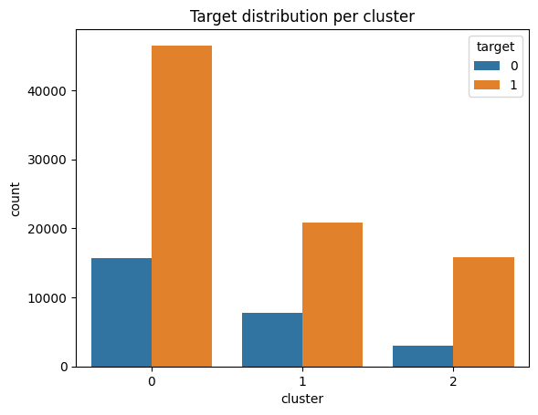

```python
pd.crosstab(df["cluster"], df["target"], normalize="index")
sns.countplot(x="cluster", hue="target", data=df)
plt.title("Target distribution per cluster")
plt.show()
```

the distribition of the clusters look the same across the target classes, indicating they do not have much relation

```python
from sklearn.metrics import adjusted_rand_score, normalized_mutual_info_score

ari = adjusted_rand_score(df["target"], df["cluster"])
nmi = normalized_mutual_info_score(df["target"], df["cluster"])

print("ARI:", ari)
print("NMI:", nmi)
```

```
ARI: -0.00996612615923151
NMI: 0.005669781934295602
```

external validation using ARI and NMI shows no meaningful alignment with the target variable.

```python
for c in df["cluster"].unique():
    print(f"\n===== Cluster {c} =====")

    print("\nTop high features:")
    display(relative_profile.loc[c].sort_values(ascending=False).head(5))

    print("\nTop low features:")
    display(relative_profile.loc[c].sort_values().head(5))
```

```
===== Cluster 0 =====

Top high features:
```

```
urban_density_index               1.216778
coverage_breadth_score            0.563071
estimated_settlement_amount       0.461767
risk_score                        0.428855
benefit_utilization_percentage    0.423525
Name: 0, dtype: float64
```

```
Top low features:
```

```
witnesses_count                  -1.389429
claim_received_to_review_hours   -0.971123
coverage_start_to_claim_months   -0.677564
coinsurance_percentage           -0.367506
loss_ratio_history               -0.312732
Name: 0, dtype: float64
```

```
===== Cluster 2 =====

Top high features:
```

```
witnesses_count                   1.724306
claim_received_to_review_hours    1.221428
coverage_start_to_claim_months    0.862485
claim_processing_days             0.771241
recovery_probability              0.706688
Name: 2, dtype: float64
```

```
Top low features:
```

```
urban_density_index              -1.557860
coverage_breadth_score           -0.719541
estimated_settlement_amount      -0.601971
benefit_utilization_percentage   -0.547487
risk_score                       -0.545866
Name: 2, dtype: float64
```

```
===== Cluster 1 =====

Top high features:
```

```
witnesses_count                   1.881328
claim_received_to_review_hours    1.304327
coverage_start_to_claim_months    0.903331
coinsurance_percentage            0.491993
loss_ratio_history                0.408580
Name: 1, dtype: float64
```

```
Top low features:
```

```
urban_density_index           -1.616342
coverage_breadth_score        -0.748866
estimated_settlement_amount   -0.606376
incurred_loss_estimate        -0.592464
risk_score                    -0.571773
Name: 1, dtype: float64
```

```python
kmeans = KMeans(n_clusters=best_k_umap3d, init="k-means++", n_init=10, random_state=42)
labels = kmeans.fit_predict(X_umap3d)

plot_3d_clusters(
    X_umap3d[:, :3],
    labels,
    kmeans.cluster_centers_[:, :3],
    f"UMAP 3D Clusters (k={best_k_umap3d})"
)
```

[output not shown]

## GMM

```python
def sampled_silhouette_safe(X, labels, sample_size=10000, random_state=42):
    labels = np.asarray(labels)
    if len(np.unique(labels)) < 2:
        return np.nan
    sample_size = min(sample_size, len(X))
    return sampled_silhouette(X, labels, sample_size=sample_size, random_state=random_state)

def sample_rows(X, max_rows=12000, random_state=42):
    if len(X) <= max_rows:
        return X
    rng = np.random.default_rng(random_state)
    idx = rng.choice(len(X), size=max_rows, replace=False)
    return X[idx]

def evaluate_gmm_full(X, k_range=range(2, 11), sample_size=10000, covariance_type='diag'):
    results = []
    for k in k_range:
        gmm = GaussianMixture(
            n_components=k,
            covariance_type=covariance_type,
            n_init=3,
            max_iter=150,
            reg_covar=1e-6,
            random_state=42
        )
        labels = gmm.fit_predict(X)
        results.append({
            'k': k,
            'silhouette_sampled': sampled_silhouette_safe(X, labels, sample_size=sample_size),
            'davies_bouldin': davies_bouldin_score(X, labels),
            'aic': gmm.aic(X),
            'bic': gmm.bic(X),
            'converged': gmm.converged_
        })
        print(f'GMM k={k} done')
    return pd.DataFrame(results)

def get_best_gmm_k(results_df):
    valid = results_df.dropna(subset=['silhouette_sampled'])
    if valid.empty:
        return int(results_df.loc[results_df['bic'].idxmin(), 'k'])
    return int(valid.loc[valid['silhouette_sampled'].idxmax(), 'k'])

def plot_gmm_metrics(results_df, title):
    k = results_df['k']
    fig, ax = plt.subplots(1, 4, figsize=(24, 4))
    ax[0].plot(k, results_df['silhouette_sampled'], marker='o')
    ax[0].set_title(f'{title} - Silhouette (sampled)')
    ax[0].set_xlabel('k')
    ax[0].set_ylabel('Score')
    ax[1].plot(k, results_df['davies_bouldin'], marker='o')
    ax[1].set_title(f'{title} - Davies-Bouldin')
    ax[1].set_xlabel('k')
    ax[1].set_ylabel('Score (lower better)')
    ax[2].plot(k, results_df['aic'], marker='o')
    ax[2].set_title(f'{title} - AIC')
    ax[2].set_xlabel('k')
    ax[2].set_ylabel('AIC')
    ax[3].plot(k, results_df['bic'], marker='o')
    ax[3].set_title(f'{title} - BIC')
    ax[3].set_xlabel('k')
    ax[3].set_ylabel('BIC')
    plt.tight_layout()
    plt.show()

def plot_gmm_3d(X, labels, means, title, axis_labels):
    fig = plt.figure(figsize=(10, 8))
    ax = fig.add_subplot(111, projection='3d')
    ax.scatter(X[:, 0], X[:, 1], X[:, 2], c=labels, cmap='tab10', s=10, alpha=0.45)
    ax.scatter(means[:, 0], means[:, 1], means[:, 2], c='black', s=200, marker='X')
    ax.set_title(title)
    ax.set_xlabel(axis_labels[0])
    ax.set_ylabel(axis_labels[1])
    ax.set_zlabel(axis_labels[2])
    plt.tight_layout()
    plt.show()

X_pca_gmm = sample_rows(data_pca.drop(columns=['target'], errors='ignore').values, max_rows=12000)
X_umap2d_gmm = sample_rows(umap_2d_df.drop(columns=['target'], errors='ignore').values, max_rows=12000)
X_umap3d_gmm = sample_rows(umap_3d_df.drop(columns=['target'], errors='ignore').values, max_rows=12000)
```

```python
gmm_results_pca = evaluate_gmm_full(X_pca_gmm)
gmm_results_umap2d = evaluate_gmm_full(X_umap2d_gmm)
gmm_results_umap3d = evaluate_gmm_full(X_umap3d_gmm)

print('\nGMM results on PCA')
display(gmm_results_pca)
print('\nGMM results on UMAP 2D')
display(gmm_results_umap2d)
print('\nGMM results on UMAP 3D')
display(gmm_results_umap3d)
```

```
GMM k=2 done
GMM k=3 done
GMM k=4 done
GMM k=5 done
GMM k=6 done
GMM k=7 done
GMM k=8 done
GMM k=9 done
GMM k=10 done
GMM k=2 done
GMM k=3 done
GMM k=4 done
GMM k=5 done
GMM k=6 done
GMM k=7 done
GMM k=8 done
GMM k=9 done
GMM k=10 done
GMM k=2 done
GMM k=3 done
GMM k=4 done
GMM k=5 done
GMM k=6 done
GMM k=7 done
GMM k=8 done
GMM k=9 done
GMM k=10 done

GMM results on PCA
```

|  | k | silhouette_sampled | davies_bouldin | aic | bic | converged |
| --- | --- | --- | --- | --- | --- | --- |
| 0 | 2 | 0.116306 | 4.802938 | 696114.887573 | 696861.546428 | True |
| 1 | 3 | 0.116616 | 4.368385 | 670787.062744 | 671910.747357 | True |
| 2 | 4 | 0.117302 | 5.140558 | 658555.261475 | 660055.971846 | True |
| 3 | 5 | -0.092440 | 5.397782 | 605396.229370 | 607273.965500 | True |
| 4 | 6 | 0.119570 | 4.680559 | 647558.196411 | 649812.958299 | True |
| 5 | 7 | -0.075273 | 4.647520 | 594001.871216 | 596633.658862 | True |
| 6 | 8 | -0.071347 | 4.863728 | 591395.512451 | 594404.325856 | True |
| 7 | 9 | -0.066164 | 4.336357 | 590372.741333 | 593758.580496 | True |
| 8 | 10 | -0.094383 | 4.580450 | 563829.141968 | 567592.006890 | True |

```
GMM results on UMAP 2D
```

|  | k | silhouette_sampled | davies_bouldin | aic | bic | converged |
| --- | --- | --- | --- | --- | --- | --- |
| 0 | 2 | 0.514141 | 0.871623 | 138531.965607 | 138598.499564 | True |
| 1 | 3 | 0.668990 | 0.515825 | 129709.312561 | 129812.809828 | True |
| 2 | 4 | 0.630943 | 0.495004 | 126950.494659 | 127090.955236 | True |
| 3 | 5 | 0.569984 | 0.620361 | 125091.239594 | 125268.663480 | True |
| 4 | 6 | 0.475878 | 0.729555 | 123592.587860 | 123806.975056 | True |
| 5 | 7 | 0.463655 | 0.755000 | 122358.294647 | 122609.645153 | True |
| 6 | 8 | 0.442835 | 0.750081 | 121561.863831 | 121850.177646 | True |
| 7 | 9 | 0.442208 | 0.768841 | 120567.335785 | 120892.612910 | True |
| 8 | 10 | 0.440706 | 0.767030 | 119293.503235 | 119655.743669 | True |

```
GMM results on UMAP 3D
```

|  | k | silhouette_sampled | davies_bouldin | aic | bic | converged |
| --- | --- | --- | --- | --- | --- | --- |
| 0 | 2 | 0.529388 | 0.892670 | 172812.067963 | 172908.172568 | True |
| 1 | 3 | 0.666611 | 0.581129 | 155234.267273 | 155382.120512 | True |
| 2 | 4 | 0.644056 | 0.485969 | 149341.330627 | 149540.932500 | True |
| 3 | 5 | 0.502327 | 0.708406 | 145683.974426 | 145935.324932 | True |
| 4 | 6 | 0.410797 | 0.794067 | 143884.371979 | 144187.471118 | True |
| 5 | 7 | 0.429448 | 0.828701 | 140984.122559 | 141338.970331 | True |
| 6 | 8 | 0.396408 | 0.886311 | 136752.753601 | 137159.350007 | True |
| 7 | 9 | 0.378898 | 0.912196 | 135180.716919 | 135639.061959 | True |
| 8 | 10 | 0.350389 | 1.118401 | 133092.620361 | 133602.714034 | True |

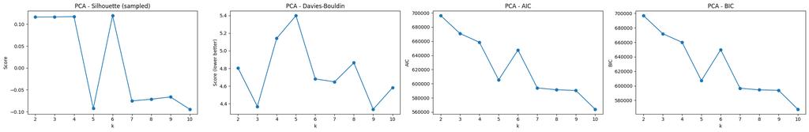

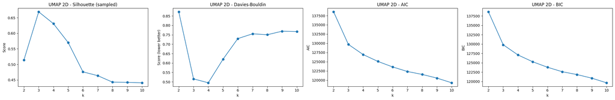

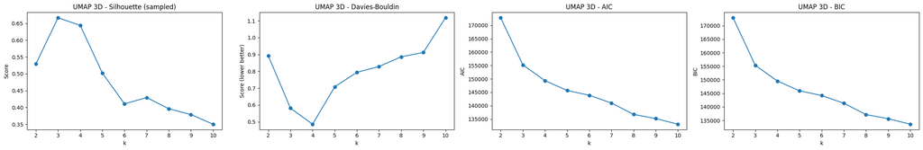

```python
plot_gmm_metrics(gmm_results_pca, 'PCA')
plot_gmm_metrics(gmm_results_umap2d, 'UMAP 2D')
plot_gmm_metrics(gmm_results_umap3d, 'UMAP 3D')
```

GMM gave the same results and chose k=3 for umap data, while in PCA data it chose k=6, but the merics says when KMeans++ chose K=2 gave better resutls.

```
Best GMM k values: 6 3 3
Cluster quality comparison: GMM vs KMeans++
```

|  | embedding | best_k_gmm | gmm_silhouette | gmm_davies_bouldin | gmm_bic | best_k_kmeans | kmeans_silhouette | kmeans_davies_bouldin |
| --- | --- | --- | --- | --- | --- | --- | --- | --- |
| 0 | PCA | 6 | 0.119570 | 4.680559 | 649812.958299 | 2 | 0.348245 | 1.716244 |
| 1 | UMAP 2D | 3 | 0.668990 | 0.515825 | 129812.809828 | 3 | 0.664785 | 0.523502 |
| 2 | UMAP 3D | 3 | 0.666611 | 0.581129 | 155382.120512 | 3 | 0.662283 | 0.591820 |

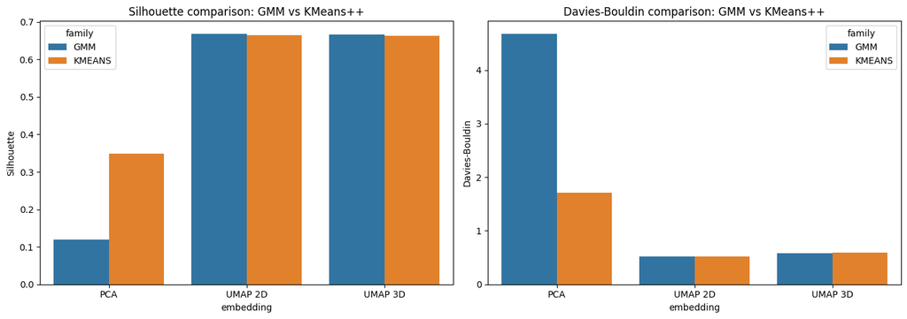

```python
best_k_gmm_pca = get_best_gmm_k(gmm_results_pca)
best_k_gmm_umap2d = get_best_gmm_k(gmm_results_umap2d)
best_k_gmm_umap3d = get_best_gmm_k(gmm_results_umap3d)

print('Best GMM k values:', best_k_gmm_pca, best_k_gmm_umap2d, best_k_gmm_umap3d)

gmm_pca = GaussianMixture(n_components=best_k_gmm_pca, covariance_type='diag', n_init=3, max_iter=150, reg_covar=1e-6, random_state=42)
gmm_umap2d = GaussianMixture(n_components=best_k_gmm_umap2d, covariance_type='diag', n_init=3, max_iter=150, reg_covar=1e-6, random_state=42)
gmm_umap3d = GaussianMixture(n_components=best_k_gmm_umap3d, covariance_type='diag', n_init=3, max_iter=150, reg_covar=1e-6, random_state=42)

gmm_labels_pca = gmm_pca.fit_predict(X_pca_gmm)
gmm_labels_umap2d = gmm_umap2d.fit_predict(X_umap2d_gmm)
gmm_labels_umap3d = gmm_umap3d.fit_predict(X_umap3d_gmm)

gmm_metrics_compare = pd.DataFrame({
    'embedding': ['PCA', 'UMAP 2D', 'UMAP 3D'],
    'best_k_gmm': [best_k_gmm_pca, best_k_gmm_umap2d, best_k_gmm_umap3d],
    'gmm_silhouette': [
        gmm_results_pca.loc[gmm_results_pca['k'] == best_k_gmm_pca, 'silhouette_sampled'].iloc[0],
        gmm_results_umap2d.loc[gmm_results_umap2d['k'] == best_k_gmm_umap2d, 'silhouette_sampled'].iloc[0],
        gmm_results_umap3d.loc[gmm_results_umap3d['k'] == best_k_gmm_umap3d, 'silhouette_sampled'].iloc[0],
    ],
    'gmm_davies_bouldin': [
        gmm_results_pca.loc[gmm_results_pca['k'] == best_k_gmm_pca, 'davies_bouldin'].iloc[0],
        gmm_results_umap2d.loc[gmm_results_umap2d['k'] == best_k_gmm_umap2d, 'davies_bouldin'].iloc[0],
        gmm_results_umap3d.loc[gmm_results_umap3d['k'] == best_k_gmm_umap3d, 'davies_bouldin'].iloc[0],
    ],
    'gmm_bic': [
        gmm_results_pca.loc[gmm_results_pca['k'] == best_k_gmm_pca, 'bic'].iloc[0],
        gmm_results_umap2d.loc[gmm_results_umap2d['k'] == best_k_gmm_umap2d, 'bic'].iloc[0],
        gmm_results_umap3d.loc[gmm_results_umap3d['k'] == best_k_gmm_umap3d, 'bic'].iloc[0],
    ]
})

kmeans_metrics_compare = pd.DataFrame({
    'embedding': ['PCA', 'UMAP 2D', 'UMAP 3D'],
    'best_k_kmeans': [best_k_pca, best_k_umap2d, best_k_umap3d],
    'kmeans_silhouette': [
        results_pca.loc[results_pca['k'] == best_k_pca, 'silhouette_sampled'].iloc[0],
        results_umap2d.loc[results_umap2d['k'] == best_k_umap2d, 'silhouette_sampled'].iloc[0],
        results_umap3d.loc[results_umap3d['k'] == best_k_umap3d, 'silhouette_sampled'].iloc[0],
    ],
    'kmeans_davies_bouldin': [
        results_pca.loc[results_pca['k'] == best_k_pca, 'davies_bouldin'].iloc[0],
        results_umap2d.loc[results_umap2d['k'] == best_k_umap2d, 'davies_bouldin'].iloc[0],
        results_umap3d.loc[results_umap3d['k'] == best_k_umap3d, 'davies_bouldin'].iloc[0],
    ]
})

comparison_df = gmm_metrics_compare.merge(kmeans_metrics_compare, on='embedding')
print('Cluster quality comparison: GMM vs KMeans++')
display(comparison_df)

comparison_long = comparison_df.melt(
    id_vars='embedding',
    value_vars=['gmm_silhouette', 'kmeans_silhouette', 'gmm_davies_bouldin', 'kmeans_davies_bouldin'],
    var_name='metric',
    value_name='value'
)
comparison_long['family'] = comparison_long['metric'].str.split('_').str[0].str.upper()
comparison_long['score_type'] = comparison_long['metric'].str.split('_').str[-1]

fig, axes = plt.subplots(1, 2, figsize=(14, 5))
sns.barplot(data=comparison_long[comparison_long['score_type'] == 'silhouette'], x='embedding', y='value', hue='family', ax=axes[0])
axes[0].set_title('Silhouette comparison: GMM vs KMeans++')
axes[0].set_ylabel('Silhouette')
sns.barplot(data=comparison_long[comparison_long['score_type'] == 'bouldin'], x='embedding', y='value', hue='family', ax=axes[1])
axes[1].set_title('Davies-Bouldin comparison: GMM vs KMeans++')
axes[1].set_ylabel('Davies-Bouldin')
plt.tight_layout()
plt.show()
```

we can cleary see that KMeans++ and GMM has about the same Silhoutte and davies-Bouldin scores in the UMAP components(GMM slightly better), while in PCA data GMM performed way worse than KMeans++

gmm_silhouette 0.11956970393657684 gmm_davies_bouldin 4.680558662069935 kmeans_silhouette 0.3482454014243486 kmeans_davies_bouldin 1.7162442988980728

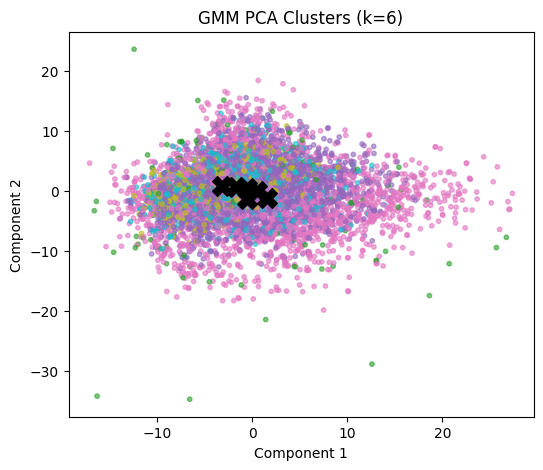

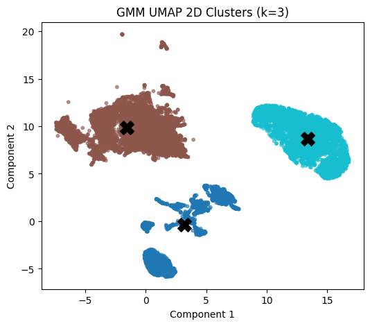

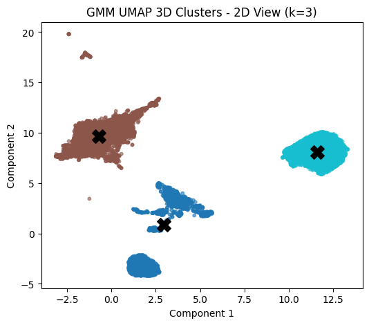

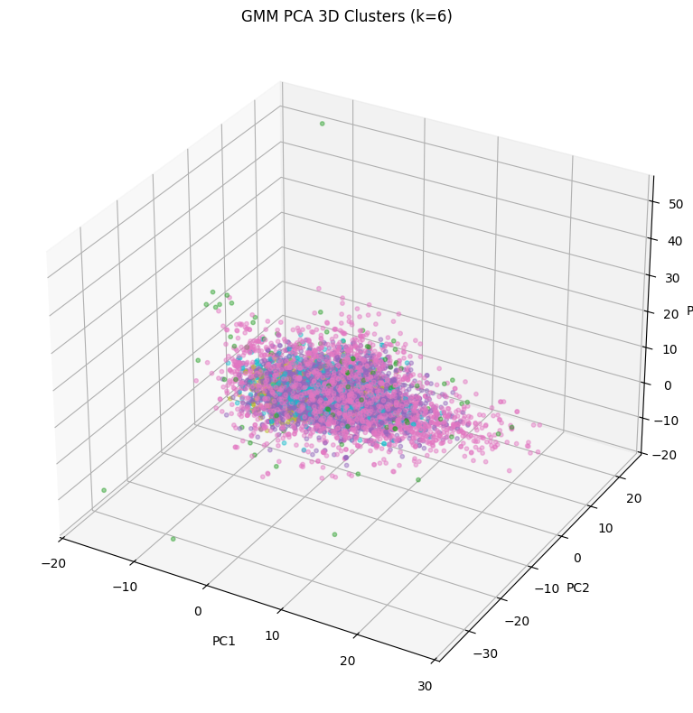

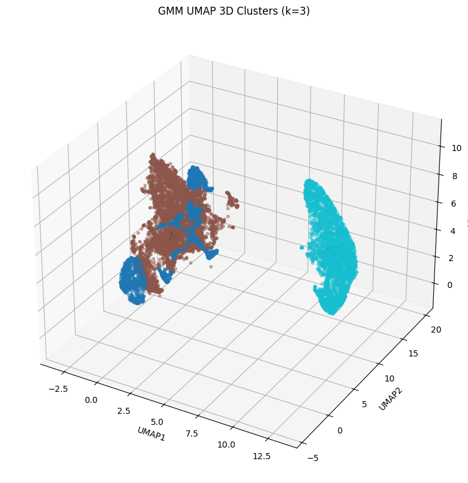

|  | PCA | UMAP 2D | UMAP 3D |
| --- | --- | --- | --- |
| 0 | 4963 | 2063 | 2058 |
| 1 | 116 | 6811 | 6818 |
| 2 | 2853 | 3126 | 3124 |
| 3 | 2179 | 0 | 0 |
| 4 | 787 | 0 | 0 |
| 5 | 1102 | 0 | 0 |

```python
plot_2d_clusters(X_pca_gmm[:, :2], gmm_labels_pca, gmm_pca.means_[:, :2], f'GMM PCA Clusters (k={best_k_gmm_pca})')
plot_2d_clusters(X_umap2d_gmm[:, :2], gmm_labels_umap2d, gmm_umap2d.means_[:, :2], f'GMM UMAP 2D Clusters (k={best_k_gmm_umap2d})')
plot_2d_clusters(X_umap3d_gmm[:, :2], gmm_labels_umap3d, gmm_umap3d.means_[:, :2], f'GMM UMAP 3D Clusters - 2D View (k={best_k_gmm_umap3d})')

plot_gmm_3d(X_pca_gmm[:, :3], gmm_labels_pca, gmm_pca.means_[:, :3], f'GMM PCA 3D Clusters (k={best_k_gmm_pca})', ['PC1', 'PC2', 'PC3'])
plot_gmm_3d(X_umap3d_gmm[:, :3], gmm_labels_umap3d, gmm_umap3d.means_[:, :3], f'GMM UMAP 3D Clusters (k={best_k_gmm_umap3d})', ['UMAP1', 'UMAP2', 'UMAP3'])

gmm_cluster_counts = pd.DataFrame({
    'PCA': pd.Series(gmm_labels_pca).value_counts().sort_index(),
    'UMAP 2D': pd.Series(gmm_labels_umap2d).value_counts().sort_index(),
    'UMAP 3D': pd.Series(gmm_labels_umap3d).value_counts().sort_index()
}).fillna(0).astype(int)
display(gmm_cluster_counts)
```

# RL

```python
target = data['target'].values

cols = data_pca.columns[:5]
X_pca = data_pca[cols].to_numpy()

N_BINS = 5
N_COMPONENTS = X_pca.shape[1]
```

```python
# ── State Discretization ─────────────────────────────────────────────────────
N_BINS = 5   # bins per PCA dimension → 5^5 = 3125 states (manageable)

def discretize(X_pca, n_bins=N_BINS):
    """Bin each PC into n_bins equal-frequency bins; return integer state IDs."""
    binned = np.zeros((len(X_pca), X_pca.shape[1]), dtype=int)
    for i in range(X_pca.shape[1]):
        quantiles = np.linspace(0, 100, n_bins + 1)
        edges = np.percentile(X_pca[:, i], quantiles)
        edges[0] -= 1e-6; edges[-1] += 1e-6
        binned[:, i] = np.digitize(X_pca[:, i], edges[1:-1])
    # Encode tuple of bins as a single integer
    multipliers = n_bins ** np.arange(X_pca.shape[1])
    return binned @ multipliers

states_all = discretize(X_pca)
N_STATES = N_BINS ** N_COMPONENTS
N_ACTIONS = 4
print(f'State space size : {N_STATES}')
print(f'Action space size: {N_ACTIONS}')
print(f'Unique observed states: {len(np.unique(states_all))}')
```

```
State space size : 3125
Action space size: 4
Unique observed states: 1672
```

```python
# ── Reward Function ───────────────────────────────────────────────────────────
def reward(action, true_label):
    """
    Actions: 0=fast-track, 1=request docs, 2=manual review, 3=deny
    true_label: 0=standard (risky/complex), 1=accelerated-eligible
    """
    if true_label == 1 and action == 0:   return +10   # correct fast-track
    if true_label == 0 and action == 2:   return  +5   # correct manual review
    if true_label == 0 and action == 3:   return  +3   # correct deny
    if true_label == 0 and action == 0:   return -15   # dangerous false fast-track
    if true_label == 1 and action == 3:   return -10   # unjust denial
    if action == 1:                        return  -1   # delay cost (docs request)
    return -5                                           # other mismatch
```

```python
# ── Episode Stream ────────────────────────────────────────────────────────────
def make_episodes(states, labels, n_episodes=4000, episode_len=50):
    """Yield (state, label) pairs per episode by random sampling from the dataset."""
    idx = np.arange(len(states))
    episodes = []
    for _ in range(n_episodes):
        chosen = np.random.choice(idx, size=episode_len, replace=True)
        episodes.append(list(zip(states[chosen], labels[chosen])))
    return episodes

N_EPISODES   = 4000
EPISODE_LEN  = 50
episodes = make_episodes(states_all, target, N_EPISODES, EPISODE_LEN)
print(f'{N_EPISODES} episodes × {EPISODE_LEN} steps = {N_EPISODES*EPISODE_LEN:,} total steps')
```

```
4000 episodes × 50 steps = 200,000 total steps
```